# Principal Components and Factor Analysis

Bud Talbot

*18 May 2017*

## Initial Principal Components and Factor Analysis of GCA data.

```r
X1516GCA_FA <- read.csv(file = "GCApost.csv", header = TRUE)
```

First look at the correlaton matrix for GCA items:

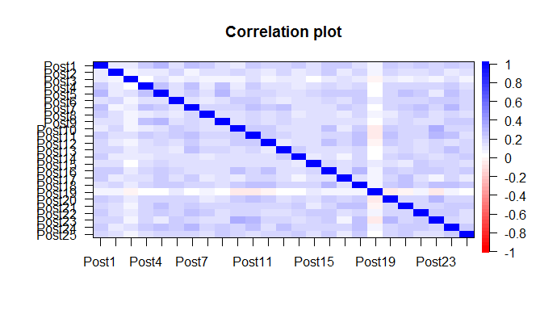

```r
library(psych)
library(GPArotation)
corPlot(X1516GCA_FA)
```

One way to determine the number of factors is to compare the solution to a set of simulated random data with properties similar to the GCA data set (a parallel analysis). Running this parallel analysis also produces the scree plot:

```
Parallel analysis suggests that the number of factors =  8  and the number of components =  3
```

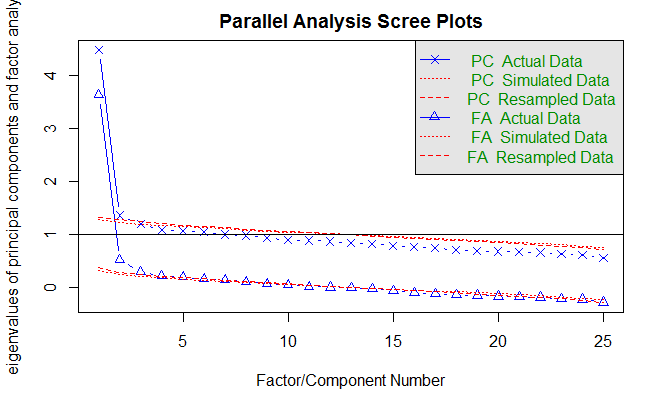

```r
fa.parallel((X1516GCA_FA))
```

The parallel analysis suggest 3 components and 8(!) factors and the scree plot shows 3-4 components with eigenvalue > 1, so run PCA (descriptive model) with 3 factors, varimax rotation

```r
principal(X1516GCA_FA, nfactors=3, rotate = "varimax")
```

```
Principal Components Analysis
Call: principal(r = X1516GCA_FA, nfactors = 3, rotate = "varimax")
Standardized loadings (pattern matrix) based upon correlation matrix
         RC1   RC2   RC3   h2   u2 com
Post1   0.51  0.07  0.20 0.30 0.70 1.3
Post2  -0.03  0.23  0.43 0.24 0.76 1.5
Post3   0.31  0.12 -0.16 0.14 0.86 1.8
Post4   0.46  0.12  0.10 0.23 0.77 1.2
Post5   0.59  0.07  0.10 0.36 0.64 1.1
Post6   0.10  0.25  0.39 0.22 0.78 1.9
Post7   0.56  0.11  0.10 0.34 0.66 1.1
Post8   0.20  0.07  0.37 0.18 0.82 1.6
Post9   0.44  0.07  0.14 0.22 0.78 1.3
Post10  0.02  0.61  0.22 0.43 0.57 1.3
Post11  0.36  0.46  0.04 0.34 0.66 1.9
Post12  0.24  0.40  0.10 0.23 0.77 1.8
Post13  0.32  0.09  0.28 0.19 0.81 2.1
Post14  0.24  0.16  0.23 0.14 0.86 2.7
Post15  0.08  0.05  0.50 0.26 0.74 1.1
Post16  0.12  0.35  0.43 0.32 0.68 2.1
Post17  0.51  0.03  0.02 0.26 0.74 1.0
Post18  0.21  0.36  0.34 0.29 0.71 2.6
Post19 -0.05 -0.48  0.55 0.53 0.47 2.0
Post20  0.22  0.53  0.09 0.33 0.67 1.4
Post21  0.44  0.19  0.16 0.25 0.75 1.6
Post22  0.27  0.13  0.39 0.25 0.75 2.0
Post23  0.00  0.65  0.23 0.48 0.52 1.3
Post24  0.47  0.07  0.30 0.32 0.68 1.7
Post25  0.25  0.15  0.34 0.20 0.80 2.3

                       RC1  RC2  RC3
SS loadings           2.74 2.22 2.08
Proportion Var        0.11 0.09 0.08
Cumulative Var        0.11 0.20 0.28
Proportion Explained  0.39 0.32 0.30
Cumulative Proportion 0.39 0.70 1.00

Mean item complexity =  1.7
Test of the hypothesis that 3 components are sufficient.

The root mean square of the residuals (RMSR) is  0.06
 with the empirical chi square  2397.9  with prob <  0

Fit based upon off diagonal values = 0.85
```

Now compare to PCA with 4 factors:

```r
principal(X1516GCA_FA, nfactors=4, rotate = "varimax")
```

```
Principal Components Analysis
Call: principal(r = X1516GCA_FA, nfactors = 4, rotate = "varimax")
Standardized loadings (pattern matrix) based upon correlation matrix
         RC2   RC1   RC3   RC4   h2   u2 com
Post1   0.06  0.34  0.19  0.39 0.31 0.69 2.5
Post2   0.27 -0.02  0.43  0.01 0.25 0.75 1.7
Post3   0.09 -0.19 -0.05  0.64 0.46 0.54 1.2
Post4   0.10  0.57  0.01  0.09 0.34 0.66 1.1
Post5   0.04  0.54  0.05  0.29 0.38 0.62 1.6
Post6   0.28  0.11  0.36  0.06 0.23 0.77 2.2
Post7   0.09  0.37  0.09  0.44 0.34 0.66 2.1
Post8   0.09  0.01  0.41  0.30 0.26 0.74 2.0
Post9   0.06  0.61  0.03  0.01 0.38 0.62 1.0
Post10  0.63  0.08  0.15  0.00 0.43 0.57 1.2
Post11  0.44  0.13  0.04  0.41 0.38 0.62 2.2
Post12  0.40  0.31  0.02  0.07 0.26 0.74 2.0
Post13  0.10  0.19  0.28  0.28 0.20 0.80 3.0
Post14  0.17  0.28  0.18  0.08 0.14 0.86 2.6
Post15  0.09  0.14  0.49  0.00 0.26 0.74 1.2
Post16  0.38  0.20  0.37  0.00 0.32 0.68 2.5
Post17  0.00  0.20  0.06  0.52 0.31 0.69 1.3
Post18  0.37  0.25  0.29  0.08 0.29 0.71 2.8
Post19 -0.42 -0.03  0.60 -0.05 0.54 0.46 1.8
Post20  0.52  0.16  0.04  0.19 0.34 0.66 1.5
Post21  0.18  0.43  0.10  0.20 0.27 0.73 1.9
Post22  0.15  0.15  0.40  0.26 0.27 0.73 2.4
Post23  0.67  0.02  0.18  0.04 0.48 0.52 1.2
Post24  0.07  0.32  0.29  0.37 0.33 0.67 3.0
Post25  0.16  0.49  0.24 -0.11 0.33 0.67 1.8

                       RC2  RC1  RC3  RC4
SS loadings           2.26 2.26 1.83 1.77
Proportion Var        0.09 0.09 0.07 0.07
Cumulative Var        0.09 0.18 0.25 0.32
Proportion Explained  0.28 0.28 0.23 0.22
Cumulative Proportion 0.28 0.56 0.78 1.00

Mean item complexity =  1.9
Test of the hypothesis that 4 components are sufficient.

The root mean square of the residuals (RMSR) is  0.06
 with the empirical chi square  2831.87  with prob <  0

Fit based upon off diagonal values = 0.82
```

Now compare the PCAs to a factor analysis (structural model) specifying 3 factors, varimax rotation, do not impute values for missing, use minimum residual factoring method (default) and view loading matrix

```r
fa(X1516GCA_FA, nfactors = 3, rotate = "varimax")
```

```
Factor Analysis using method =  minres
Call: fa(r = X1516GCA_FA, nfactors = 3, rotate = "varimax")
Standardized loadings (pattern matrix) based upon correlation matrix
        MR1  MR2   MR3   h2   u2 com
Post1  0.44 0.17  0.03 0.22 0.78 1.3
Post2  0.09 0.33  0.08 0.12 0.88 1.3
Post3  0.18 0.04 -0.07 0.04 0.96 1.4
Post4  0.38 0.15 -0.03 0.16 0.84 1.3
Post5  0.49 0.13  0.01 0.25 0.75 1.1
Post6  0.17 0.34  0.05 0.15 0.85 1.5
Post7  0.47 0.15 -0.04 0.25 0.75 1.2
Post8  0.23 0.23  0.08 0.11 0.89 2.3
Post9  0.35 0.15  0.01 0.15 0.85 1.3
Post10 0.11 0.49 -0.18 0.28 0.72 1.4
Post11 0.34 0.31 -0.21 0.25 0.75 2.7
Post12 0.25 0.29 -0.11 0.16 0.84 2.3
Post13 0.29 0.22  0.05 0.14 0.86 1.9
Post14 0.23 0.22  0.03 0.11 0.89 2.0
Post15 0.17 0.28  0.15 0.13 0.87 2.3
Post16 0.20 0.44  0.06 0.23 0.77 1.4
Post17 0.37 0.08  0.00 0.14 0.86 1.1
Post18 0.26 0.40  0.01 0.23 0.77 1.7
Post19 0.00 0.02  0.42 0.18 0.82 1.0
Post20 0.24 0.36 -0.20 0.23 0.77 2.4
Post21 0.38 0.22 -0.02 0.19 0.81 1.6
Post22 0.29 0.30  0.09 0.18 0.82 2.2
Post23 0.09 0.54 -0.24 0.35 0.65 1.4
Post24 0.43 0.23  0.09 0.24 0.76 1.6
Post25 0.27 0.27  0.08 0.15 0.85 2.2

                       MR1  MR2  MR3
SS loadings           2.20 2.02 0.44
Proportion Var        0.09 0.08 0.02
Cumulative Var        0.09 0.17 0.19
Proportion Explained  0.47 0.43 0.09
Cumulative Proportion 0.47 0.91 1.00

Mean item complexity =  1.7
Test of the hypothesis that 3 factors are sufficient.

The degrees of freedom for the null model are  300  and the objective function was  2.85 with Chi Square of  3314.6
The degrees of freedom for the model are 228  and the objective function was  0.32

The root mean square of the residuals (RMSR) is  0.03
The df corrected root mean square of the residuals is  0.03

The harmonic number of observations is  989 with the empirical chi square  418.44  with prob <  2.2e-13
The total number of observations was  1173  with Likelihood Chi Square =  370.31  with prob <  7.4e-09

Tucker Lewis Index of factoring reliability =  0.938
RMSEA index =  0.023  and the 90 % confidence intervals are  0.019 0.027
BIC =  -1241.04
Fit based upon off diagonal values = 0.97
Measures of factor score adequacy
                                                MR1  MR2   MR3
Correlation of scores with factors             0.79 0.78  0.59
Multiple R square of scores with factors       0.63 0.61  0.35
Minimum correlation of possible factor scores  0.26 0.22 -0.30
```

And finally run the FA with 4 factors:

```r
fa(X1516GCA_FA, nfactors = 4, rotate = "varimax")
```

```
Factor Analysis using method =  minres
Call: fa(r = X1516GCA_FA, nfactors = 4, rotate = "varimax")
Standardized loadings (pattern matrix) based upon correlation matrix
        MR2   MR1  MR4   MR3    h2   u2 com
Post1  0.16  0.34 0.28 -0.01 0.218 0.78 2.4
Post2  0.33  0.07 0.08 -0.05 0.126 0.87 1.3
Post3  0.03  0.14 0.11  0.08 0.039 0.96 2.6
Post4  0.15  0.33 0.19  0.05 0.166 0.83 2.1
Post5  0.14  0.59 0.07  0.01 0.368 0.63 1.2
Post6  0.32  0.11 0.18 -0.01 0.146 0.85 1.8
Post7  0.08  0.29 0.45  0.08 0.297 0.70 1.9
Post8  0.20  0.10 0.28 -0.06 0.131 0.87 2.2
Post9  0.15  0.35 0.13  0.01 0.163 0.84 1.7
Post10 0.46  0.06 0.12  0.22 0.278 0.72 1.7
Post11 0.25  0.20 0.31  0.26 0.269 0.73 3.7
Post12 0.28  0.23 0.11  0.14 0.166 0.83 2.8
Post13 0.17  0.12 0.37 -0.02 0.179 0.82 1.7
Post14 0.21  0.16 0.19 -0.01 0.106 0.89 2.9
Post15 0.28  0.13 0.13 -0.12 0.126 0.87 2.4
Post16 0.48  0.23 0.03 -0.04 0.289 0.71 1.5
Post17 0.08  0.33 0.17  0.02 0.145 0.86 1.7
Post18 0.39  0.20 0.18  0.03 0.229 0.77 2.0
Post19 0.03 -0.02 0.06 -0.40 0.166 0.83 1.1
Post20 0.34  0.21 0.13  0.23 0.232 0.77 2.8
Post21 0.21  0.31 0.23  0.04 0.192 0.81 2.7
Post22 0.28  0.21 0.23 -0.06 0.181 0.82 2.9
Post23 0.49 -0.02 0.20  0.29 0.364 0.64 2.0
Post24 0.18  0.25 0.42 -0.05 0.279 0.72 2.1
Post25 0.28  0.22 0.17 -0.06 0.157 0.84 2.7

                       MR2  MR1  MR4  MR3
SS loadings           1.84 1.47 1.21 0.49
Proportion Var        0.07 0.06 0.05 0.02
Cumulative Var        0.07 0.13 0.18 0.20
Proportion Explained  0.37 0.29 0.24 0.10
Cumulative Proportion 0.37 0.66 0.90 1.00

Mean item complexity =  2.1
Test of the hypothesis that 4 factors are sufficient.

The degrees of freedom for the null model are  300  and the objective function was  2.85 with Chi Square of  3314.6
The degrees of freedom for the model are 206  and the objective function was  0.27

The root mean square of the residuals (RMSR) is  0.02
The df corrected root mean square of the residuals is  0.03

The harmonic number of observations is  989 with the empirical chi square  343.3  with prob <  6.1e-09
The total number of observations was  1173  with Likelihood Chi Square =  308.87  with prob <  4.5e-06

Tucker Lewis Index of factoring reliability =  0.95
RMSEA index =  0.021  and the 90 % confidence intervals are  0.016 0.025
BIC =  -1147
Fit based upon off diagonal values = 0.97
Measures of factor score adequacy
                                                MR2  MR1   MR4   MR3
Correlation of scores with factors             0.76 0.73  0.66  0.60
Multiple R square of scores with factors       0.58 0.53  0.44  0.36
Minimum correlation of possible factor scores  0.17 0.05 -0.12 -0.27
```

The 4 factor FA only accounts for 1% more variance than the 3 factor FA, and is likely harder to interpret. Also the communalities (variance accounted for in each item by all factors in the solution) does not increase much for 4 factors versus 3.